# Risk Factor Analysis

## Outcome Variable

**Outcome Variable:** ever_stunted

## Predictor Variables

**Intervention Variable:** hfoodsec

**Adjustment Set:**

unadjusted

## Stratifying Variables

The analysis was stratified on these variable(s):

- agecat
- studyid
- country

## Data Summary

| agecat | studyid | country | hfoodsec | ever_stunted | n_cell | n |
| --- | --- | --- | --- | --- | --- | --- |
| 0-6 months | ki0047075b-MAL-ED | BANGLADESH | Food Secure | 0 | 137 | 194 |
| 0-6 months | ki0047075b-MAL-ED | BANGLADESH | Food Secure | 1 | 24 | 194 |
| 0-6 months | ki0047075b-MAL-ED | BANGLADESH | Mildly Food Insecure | 0 | 3 | 194 |
| 0-6 months | ki0047075b-MAL-ED | BANGLADESH | Mildly Food Insecure | 1 | 1 | 194 |
| 0-6 months | ki0047075b-MAL-ED | BANGLADESH | Moderately Food Insecure | 0 | 20 | 194 |
| 0-6 months | ki0047075b-MAL-ED | BANGLADESH | Moderately Food Insecure | 1 | 3 | 194 |
| 0-6 months | ki0047075b-MAL-ED | BANGLADESH | Severely Food Insecure | 0 | 4 | 194 |
| 0-6 months | ki0047075b-MAL-ED | BANGLADESH | Severely Food Insecure | 1 | 2 | 194 |
| 0-6 months | ki0047075b-MAL-ED | BRAZIL | Food Secure | 0 | 3 | 129 |
| 0-6 months | ki0047075b-MAL-ED | BRAZIL | Food Secure | 1 | 0 | 129 |
| 0-6 months | ki0047075b-MAL-ED | BRAZIL | Mildly Food Insecure | 0 | 10 | 129 |
| 0-6 months | ki0047075b-MAL-ED | BRAZIL | Mildly Food Insecure | 1 | 1 | 129 |
| 0-6 months | ki0047075b-MAL-ED | BRAZIL | Moderately Food Insecure | 0 | 57 | 129 |
| 0-6 months | ki0047075b-MAL-ED | BRAZIL | Moderately Food Insecure | 1 | 10 | 129 |
| 0-6 months | ki0047075b-MAL-ED | BRAZIL | Severely Food Insecure | 0 | 46 | 129 |
| 0-6 months | ki0047075b-MAL-ED | BRAZIL | Severely Food Insecure | 1 | 2 | 129 |
| 0-6 months | ki0047075b-MAL-ED | INDIA | Food Secure | 0 | 161 | 212 |
| 0-6 months | ki0047075b-MAL-ED | INDIA | Food Secure | 1 | 29 | 212 |
| 0-6 months | ki0047075b-MAL-ED | INDIA | Mildly Food Insecure | 0 | 5 | 212 |
| 0-6 months | ki0047075b-MAL-ED | INDIA | Mildly Food Insecure | 1 | 0 | 212 |
| 0-6 months | ki0047075b-MAL-ED | INDIA | Moderately Food Insecure | 0 | 3 | 212 |
| 0-6 months | ki0047075b-MAL-ED | INDIA | Moderately Food Insecure | 1 | 1 | 212 |
| 0-6 months | ki0047075b-MAL-ED | INDIA | Severely Food Insecure | 0 | 11 | 212 |
| 0-6 months | ki0047075b-MAL-ED | INDIA | Severely Food Insecure | 1 | 2 | 212 |
| 0-6 months | ki0047075b-MAL-ED | NEPAL | Food Secure | 0 | 86 | 128 |
| 0-6 months | ki0047075b-MAL-ED | NEPAL | Food Secure | 1 | 8 | 128 |
| 0-6 months | ki0047075b-MAL-ED | NEPAL | Mildly Food Insecure | 0 | 13 | 128 |
| 0-6 months | ki0047075b-MAL-ED | NEPAL | Mildly Food Insecure | 1 | 2 | 128 |
| 0-6 months | ki0047075b-MAL-ED | NEPAL | Moderately Food Insecure | 0 | 12 | 128 |
| 0-6 months | ki0047075b-MAL-ED | NEPAL | Moderately Food Insecure | 1 | 4 | 128 |

[output cut: 222 more lines]

The following strata were considered:

- agecat: 0-24 months, studyid: ki0047075b-MAL-ED, country: BANGLADESH
- agecat: 0-24 months, studyid: ki0047075b-MAL-ED, country: BRAZIL
- agecat: 0-24 months, studyid: ki0047075b-MAL-ED, country: INDIA
- agecat: 0-24 months, studyid: ki0047075b-MAL-ED, country: NEPAL
- agecat: 0-24 months, studyid: ki0047075b-MAL-ED, country: PERU
- agecat: 0-24 months, studyid: ki0047075b-MAL-ED, country: SOUTH AFRICA
- agecat: 0-24 months, studyid: ki1017093-NIH-Birth, country: BANGLADESH
- agecat: 0-24 months, studyid: ki1017093c-NIH-Crypto, country: BANGLADESH
- agecat: 0-24 months, studyid: ki1113344-GMS-Nepal, country: NEPAL
- agecat: 0-24 months, studyid: kiGH5241-JiVitA-3, country: BANGLADESH
- agecat: 0-24 months, studyid: kiGH5241-JiVitA-4, country: BANGLADESH
- agecat: 0-6 months, studyid: ki0047075b-MAL-ED, country: BANGLADESH
- agecat: 0-6 months, studyid: ki0047075b-MAL-ED, country: BRAZIL
- agecat: 0-6 months, studyid: ki0047075b-MAL-ED, country: INDIA
- agecat: 0-6 months, studyid: ki0047075b-MAL-ED, country: NEPAL
- agecat: 0-6 months, studyid: ki0047075b-MAL-ED, country: PERU
- agecat: 0-6 months, studyid: ki0047075b-MAL-ED, country: SOUTH AFRICA
- agecat: 0-6 months, studyid: ki1017093-NIH-Birth, country: BANGLADESH
- agecat: 0-6 months, studyid: ki1017093c-NIH-Crypto, country: BANGLADESH
- agecat: 0-6 months, studyid: ki1113344-GMS-Nepal, country: NEPAL
- agecat: 0-6 months, studyid: kiGH5241-JiVitA-3, country: BANGLADESH
- agecat: 0-6 months, studyid: kiGH5241-JiVitA-4, country: BANGLADESH
- agecat: 6-24 months, studyid: ki0047075b-MAL-ED, country: BANGLADESH
- agecat: 6-24 months, studyid: ki0047075b-MAL-ED, country: BRAZIL
- agecat: 6-24 months, studyid: ki0047075b-MAL-ED, country: INDIA
- agecat: 6-24 months, studyid: ki0047075b-MAL-ED, country: NEPAL
- agecat: 6-24 months, studyid: ki0047075b-MAL-ED, country: PERU
- agecat: 6-24 months, studyid: ki0047075b-MAL-ED, country: SOUTH AFRICA
- agecat: 6-24 months, studyid: ki1017093-NIH-Birth, country: BANGLADESH
- agecat: 6-24 months, studyid: ki1017093c-NIH-Crypto, country: BANGLADESH
- agecat: 6-24 months, studyid: ki1113344-GMS-Nepal, country: NEPAL
- agecat: 6-24 months, studyid: kiGH5241-JiVitA-3, country: BANGLADESH
- agecat: 6-24 months, studyid: kiGH5241-JiVitA-4, country: BANGLADESH

### Dropped Strata

Some strata were dropped due to rare outcomes:

- agecat: 0-6 months, studyid: ki0047075b-MAL-ED, country: BANGLADESH
- agecat: 0-6 months, studyid: ki0047075b-MAL-ED, country: BRAZIL
- agecat: 0-6 months, studyid: ki0047075b-MAL-ED, country: INDIA
- agecat: 0-6 months, studyid: ki0047075b-MAL-ED, country: NEPAL
- agecat: 0-6 months, studyid: ki0047075b-MAL-ED, country: PERU
- agecat: 0-6 months, studyid: ki0047075b-MAL-ED, country: SOUTH AFRICA
- agecat: 0-6 months, studyid: ki1017093-NIH-Birth, country: BANGLADESH
- agecat: 0-6 months, studyid: ki1113344-GMS-Nepal, country: NEPAL
- agecat: 6-24 months, studyid: ki0047075b-MAL-ED, country: BANGLADESH
- agecat: 6-24 months, studyid: ki0047075b-MAL-ED, country: BRAZIL
- agecat: 6-24 months, studyid: ki0047075b-MAL-ED, country: INDIA
- agecat: 6-24 months, studyid: ki0047075b-MAL-ED, country: NEPAL
- agecat: 6-24 months, studyid: ki0047075b-MAL-ED, country: SOUTH AFRICA
- agecat: 6-24 months, studyid: ki1017093-NIH-Birth, country: BANGLADESH
- agecat: 6-24 months, studyid: ki1017093c-NIH-Crypto, country: BANGLADESH
- agecat: 0-24 months, studyid: ki0047075b-MAL-ED, country: BANGLADESH
- agecat: 0-24 months, studyid: ki0047075b-MAL-ED, country: BRAZIL
- agecat: 0-24 months, studyid: ki0047075b-MAL-ED, country: INDIA
- agecat: 0-24 months, studyid: ki0047075b-MAL-ED, country: NEPAL
- agecat: 0-24 months, studyid: ki0047075b-MAL-ED, country: SOUTH AFRICA
- agecat: 0-24 months, studyid: ki1017093-NIH-Birth, country: BANGLADESH

## Methods Detail

We’re interested in the causal parameters $E[Y_a]$ for all values of $a \in \mathcal{A}$. These parameters represent the mean outcome if, possibly contrary to fact, we intervened to set all units to have $A=a$. Under the randomization and positivity assumptions, these are identified by the statistical parameters $\psi_a=E_W[E_{Y|A,W}(Y|A=a,W)]$. In addition, we’re interested in the mean of $Y$, $E[Y]$ under no intervention (the observed mean). We will estimate these parameters by using SuperLearner to fit the relevant likelihood factors – $E_{Y|A,W}(Y|A=a,W)$ and $p(A=a|W)$, and then updating our likelihood fit using a joint TMLE.

For unadjusted analyses ($W=\{\}$), initial likelihoods were estimated using Lrnr_glm to estimate the simple $E(Y|A)$ and Lrnr_mean to estimate $p(A)$. For adjusted analyses, a small library containing Lrnr_glmnet, Lrnr_xgboost, and Lrnr_mean was used.

Having estimated these parameters, we will then use the delta method to estimate relative risks and attributable risks relative to a prespecified baseline level of $A$.

# Results Detail

## Results Plots

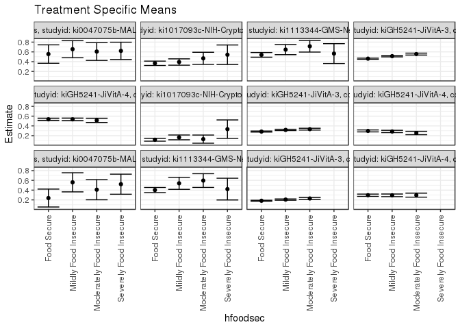

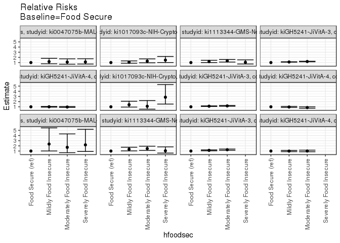

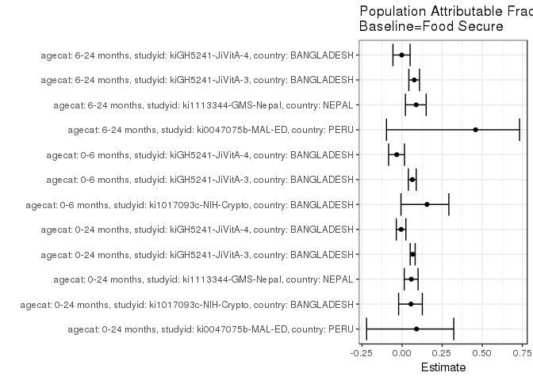

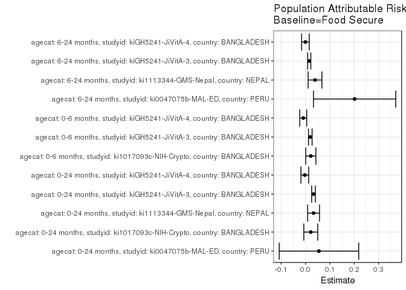

## Results Table

### Parameter: TSM

| agecat | studyid | country | intervention_level | baseline_level | estimate | ci_lower | ci_upper |
| --- | --- | --- | --- | --- | --- | --- | --- |
| 0-24 months | ki0047075b-MAL-ED | PERU | Food Secure | NA | 0.5555556 | 0.3672909 | 0.7438203 |
| 0-24 months | ki0047075b-MAL-ED | PERU | Mildly Food Insecure | NA | 0.6551724 | 0.4814091 | 0.8289357 |
| 0-24 months | ki0047075b-MAL-ED | PERU | Moderately Food Insecure | NA | 0.6071429 | 0.4254399 | 0.7888458 |
| 0-24 months | ki0047075b-MAL-ED | PERU | Severely Food Insecure | NA | 0.6206897 | 0.4433059 | 0.7980734 |
| 0-24 months | ki1017093c-NIH-Crypto | BANGLADESH | Food Secure | NA | 0.3664459 | 0.3220460 | 0.4108459 |
| 0-24 months | ki1017093c-NIH-Crypto | BANGLADESH | Mildly Food Insecure | NA | 0.3926941 | 0.3279733 | 0.4574148 |
| 0-24 months | ki1017093c-NIH-Crypto | BANGLADESH | Moderately Food Insecure | NA | 0.4677419 | 0.3434614 | 0.5920225 |
| 0-24 months | ki1017093c-NIH-Crypto | BANGLADESH | Severely Food Insecure | NA | 0.5416667 | 0.3421928 | 0.7411405 |
| 0-24 months | ki1113344-GMS-Nepal | NEPAL | Food Secure | NA | 0.5390071 | 0.4914632 | 0.5865509 |
| 0-24 months | ki1113344-GMS-Nepal | NEPAL | Mildly Food Insecure | NA | 0.6463415 | 0.5427709 | 0.7499120 |
| 0-24 months | ki1113344-GMS-Nepal | NEPAL | Moderately Food Insecure | NA | 0.7142857 | 0.5958649 | 0.8327066 |
| 0-24 months | ki1113344-GMS-Nepal | NEPAL | Severely Food Insecure | NA | 0.5652174 | 0.3624490 | 0.7679857 |
| 0-24 months | kiGH5241-JiVitA-3 | BANGLADESH | Food Secure | NA | 0.4613174 | 0.4496518 | 0.4729830 |
| 0-24 months | kiGH5241-JiVitA-3 | BANGLADESH | Mildly Food Insecure | NA | 0.5126167 | 0.4980709 | 0.5271625 |
| 0-24 months | kiGH5241-JiVitA-3 | BANGLADESH | Moderately Food Insecure | NA | 0.5549033 | 0.5351325 | 0.5746741 |
| 0-24 months | kiGH5241-JiVitA-4 | BANGLADESH | Food Secure | NA | 0.5347399 | 0.5122183 | 0.5572615 |
| 0-24 months | kiGH5241-JiVitA-4 | BANGLADESH | Mildly Food Insecure | NA | 0.5341551 | 0.5085164 | 0.5597938 |
| 0-24 months | kiGH5241-JiVitA-4 | BANGLADESH | Moderately Food Insecure | NA | 0.5128205 | 0.4694981 | 0.5561429 |
| 0-6 months | ki1017093c-NIH-Crypto | BANGLADESH | Food Secure | NA | 0.1169978 | 0.0873798 | 0.1466158 |
| 0-6 months | ki1017093c-NIH-Crypto | BANGLADESH | Mildly Food Insecure | NA | 0.1643836 | 0.1152650 | 0.2135021 |
| 0-6 months | ki1017093c-NIH-Crypto | BANGLADESH | Moderately Food Insecure | NA | 0.1290323 | 0.0455318 | 0.2125328 |
| 0-6 months | ki1017093c-NIH-Crypto | BANGLADESH | Severely Food Insecure | NA | 0.3333333 | 0.1446112 | 0.5220555 |
| 0-6 months | kiGH5241-JiVitA-3 | BANGLADESH | Food Secure | NA | 0.2840503 | 0.2735045 | 0.2945961 |
| 0-6 months | kiGH5241-JiVitA-3 | BANGLADESH | Mildly Food Insecure | NA | 0.3177716 | 0.3046385 | 0.3309047 |
| 0-6 months | kiGH5241-JiVitA-3 | BANGLADESH | Moderately Food Insecure | NA | 0.3331023 | 0.3146751 | 0.3515294 |
| 0-6 months | kiGH5241-JiVitA-4 | BANGLADESH | Food Secure | NA | 0.2971098 | 0.2768888 | 0.3173308 |
| 0-6 months | kiGH5241-JiVitA-4 | BANGLADESH | Mildly Food Insecure | NA | 0.2860274 | 0.2625975 | 0.3094573 |
| 0-6 months | kiGH5241-JiVitA-4 | BANGLADESH | Moderately Food Insecure | NA | 0.2544643 | 0.2194339 | 0.2894947 |
| 6-24 months | ki0047075b-MAL-ED | PERU | Food Secure | NA | 0.2380952 | 0.0549213 | 0.4212691 |
| 6-24 months | ki0047075b-MAL-ED | PERU | Mildly Food Insecure | NA | 0.5600000 | 0.3643419 | 0.7556581 |
| 6-24 months | ki0047075b-MAL-ED | PERU | Moderately Food Insecure | NA | 0.4090909 | 0.2025023 | 0.6156796 |
| 6-24 months | ki0047075b-MAL-ED | PERU | Severely Food Insecure | NA | 0.5217391 | 0.3164610 | 0.7270173 |
| 6-24 months | ki1113344-GMS-Nepal | NEPAL | Food Secure | NA | 0.4023669 | 0.3500329 | 0.4547008 |
| 6-24 months | ki1113344-GMS-Nepal | NEPAL | Mildly Food Insecure | NA | 0.5396825 | 0.4164739 | 0.6628912 |
| 6-24 months | ki1113344-GMS-Nepal | NEPAL | Moderately Food Insecure | NA | 0.5957447 | 0.4552944 | 0.7361950 |
| 6-24 months | ki1113344-GMS-Nepal | NEPAL | Severely Food Insecure | NA | 0.4210526 | 0.1988115 | 0.6432938 |
| 6-24 months | kiGH5241-JiVitA-3 | BANGLADESH | Food Secure | NA | 0.1825822 | 0.1729251 | 0.1922393 |
| 6-24 months | kiGH5241-JiVitA-3 | BANGLADESH | Mildly Food Insecure | NA | 0.2066344 | 0.1935233 | 0.2197456 |
| 6-24 months | kiGH5241-JiVitA-3 | BANGLADESH | Moderately Food Insecure | NA | 0.2292899 | 0.2092219 | 0.2493580 |
| 6-24 months | kiGH5241-JiVitA-4 | BANGLADESH | Food Secure | NA | 0.2956204 | 0.2724461 | 0.3187948 |
| 6-24 months | kiGH5241-JiVitA-4 | BANGLADESH | Mildly Food Insecure | NA | 0.2933071 | 0.2663308 | 0.3202834 |
| 6-24 months | kiGH5241-JiVitA-4 | BANGLADESH | Moderately Food Insecure | NA | 0.2971530 | 0.2562475 | 0.3380586 |

### Parameter: E(Y)

| agecat | studyid | country | intervention_level | baseline_level | estimate | ci_lower | ci_upper |
| --- | --- | --- | --- | --- | --- | --- | --- |
| 0-24 months | ki0047075b-MAL-ED | PERU | NA | NA | 0.6106195 | 0.5203145 | 0.7009244 |
| 0-24 months | ki1017093c-NIH-Crypto | BANGLADESH | NA | NA | 0.3878628 | 0.3531521 | 0.4225735 |
| 0-24 months | ki1113344-GMS-Nepal | NEPAL | NA | NA | 0.5719178 | 0.5317531 | 0.6120825 |
| 0-24 months | kiGH5241-JiVitA-3 | BANGLADESH | NA | NA | 0.4939877 | 0.4845041 | 0.5034712 |
| 0-24 months | kiGH5241-JiVitA-4 | BANGLADESH | NA | NA | 0.5316784 | 0.5154699 | 0.5478869 |
| 0-6 months | ki1017093c-NIH-Crypto | BANGLADESH | NA | NA | 0.1385224 | 0.1139141 | 0.1631308 |
| 0-6 months | kiGH5241-JiVitA-3 | BANGLADESH | NA | NA | 0.3034415 | 0.2954544 | 0.3114286 |
| 0-6 months | kiGH5241-JiVitA-4 | BANGLADESH | NA | NA | 0.2875098 | 0.2736314 | 0.3013882 |
| 6-24 months | ki0047075b-MAL-ED | PERU | NA | NA | 0.4395604 | 0.3370187 | 0.5421021 |
| 6-24 months | ki1113344-GMS-Nepal | NEPAL | NA | NA | 0.4411135 | 0.3960326 | 0.4861943 |
| 6-24 months | kiGH5241-JiVitA-3 | BANGLADESH | NA | NA | 0.1975885 | 0.1894938 | 0.2056833 |
| 6-24 months | kiGH5241-JiVitA-4 | BANGLADESH | NA | NA | 0.2949977 | 0.2786041 | 0.3113912 |

### Parameter: RR

| agecat | studyid | country | intervention_level | baseline_level | estimate | ci_lower | ci_upper |
| --- | --- | --- | --- | --- | --- | --- | --- |
| 0-24 months | ki0047075b-MAL-ED | PERU | Food Secure | Food Secure | 1.0000000 | 1.0000000 | 1.000000 |
| 0-24 months | ki0047075b-MAL-ED | PERU | Mildly Food Insecure | Food Secure | 1.1793103 | 0.7669045 | 1.813489 |
| 0-24 months | ki0047075b-MAL-ED | PERU | Moderately Food Insecure | Food Secure | 1.0928571 | 0.6953680 | 1.717561 |
| 0-24 months | ki0047075b-MAL-ED | PERU | Severely Food Insecure | Food Secure | 1.1172414 | 0.7171773 | 1.740474 |
| 0-24 months | ki1017093c-NIH-Crypto | BANGLADESH | Food Secure | Food Secure | 1.0000000 | 1.0000000 | 1.000000 |
| 0-24 months | ki1017093c-NIH-Crypto | BANGLADESH | Mildly Food Insecure | Food Secure | 1.0716290 | 0.8733862 | 1.314869 |
| 0-24 months | ki1017093c-NIH-Crypto | BANGLADESH | Moderately Food Insecure | Food Secure | 1.2764283 | 0.9531722 | 1.709313 |
| 0-24 months | ki1017093c-NIH-Crypto | BANGLADESH | Severely Food Insecure | Food Secure | 1.4781627 | 1.0031250 | 2.178158 |
| 0-24 months | ki1113344-GMS-Nepal | NEPAL | Food Secure | Food Secure | 1.0000000 | 1.0000000 | 1.000000 |
| 0-24 months | ki1113344-GMS-Nepal | NEPAL | Mildly Food Insecure | Food Secure | 1.1991335 | 0.9986858 | 1.439813 |
| 0-24 months | ki1113344-GMS-Nepal | NEPAL | Moderately Food Insecure | Food Secure | 1.3251880 | 1.0982970 | 1.598951 |
| 0-24 months | ki1113344-GMS-Nepal | NEPAL | Severely Food Insecure | Food Secure | 1.0486270 | 0.7247365 | 1.517267 |
| 0-24 months | kiGH5241-JiVitA-3 | BANGLADESH | Food Secure | Food Secure | 1.0000000 | 1.0000000 | 1.000000 |
| 0-24 months | kiGH5241-JiVitA-3 | BANGLADESH | Mildly Food Insecure | Food Secure | 1.1112017 | 1.0732861 | 1.150457 |
| 0-24 months | kiGH5241-JiVitA-3 | BANGLADESH | Moderately Food Insecure | Food Secure | 1.2028667 | 1.1549244 | 1.252799 |
| 0-24 months | kiGH5241-JiVitA-4 | BANGLADESH | Food Secure | Food Secure | 1.0000000 | 1.0000000 | 1.000000 |
| 0-24 months | kiGH5241-JiVitA-4 | BANGLADESH | Mildly Food Insecure | Food Secure | 0.9989064 | 0.9373509 | 1.064504 |
| 0-24 months | kiGH5241-JiVitA-4 | BANGLADESH | Moderately Food Insecure | Food Secure | 0.9590092 | 0.8720759 | 1.054609 |
| 0-6 months | ki1017093c-NIH-Crypto | BANGLADESH | Food Secure | Food Secure | 1.0000000 | 1.0000000 | 1.000000 |
| 0-6 months | ki1017093c-NIH-Crypto | BANGLADESH | Mildly Food Insecure | Food Secure | 1.4050142 | 0.9497314 | 2.078551 |
| 0-6 months | ki1017093c-NIH-Crypto | BANGLADESH | Moderately Food Insecure | Food Secure | 1.1028606 | 0.5504746 | 2.209551 |
| 0-6 months | ki1017093c-NIH-Crypto | BANGLADESH | Severely Food Insecure | Food Secure | 2.8490566 | 1.5323508 | 5.297171 |
| 0-6 months | kiGH5241-JiVitA-3 | BANGLADESH | Food Secure | Food Secure | 1.0000000 | 1.0000000 | 1.000000 |
| 0-6 months | kiGH5241-JiVitA-3 | BANGLADESH | Mildly Food Insecure | Food Secure | 1.1187160 | 1.0603898 | 1.180251 |
| 0-6 months | kiGH5241-JiVitA-3 | BANGLADESH | Moderately Food Insecure | Food Secure | 1.1726876 | 1.0977272 | 1.252767 |
| 0-6 months | kiGH5241-JiVitA-4 | BANGLADESH | Food Secure | Food Secure | 1.0000000 | 1.0000000 | 1.000000 |
| 0-6 months | kiGH5241-JiVitA-4 | BANGLADESH | Mildly Food Insecure | Food Secure | 0.9626992 | 0.8634914 | 1.073305 |
| 0-6 months | kiGH5241-JiVitA-4 | BANGLADESH | Moderately Food Insecure | Food Secure | 0.8564654 | 0.7338169 | 0.999613 |
| 6-24 months | ki0047075b-MAL-ED | PERU | Food Secure | Food Secure | 1.0000000 | 1.0000000 | 1.000000 |
| 6-24 months | ki0047075b-MAL-ED | PERU | Mildly Food Insecure | Food Secure | 2.3520000 | 1.0103684 | 5.475136 |
| 6-24 months | ki0047075b-MAL-ED | PERU | Moderately Food Insecure | Food Secure | 1.7181818 | 0.6845464 | 4.312562 |
| 6-24 months | ki0047075b-MAL-ED | PERU | Severely Food Insecure | Food Secure | 2.1913043 | 0.9234812 | 5.199689 |
| 6-24 months | ki1113344-GMS-Nepal | NEPAL | Food Secure | Food Secure | 1.0000000 | 1.0000000 | 1.000000 |
| 6-24 months | ki1113344-GMS-Nepal | NEPAL | Mildly Food Insecure | Food Secure | 1.3412698 | 1.0313490 | 1.744322 |
| 6-24 months | ki1113344-GMS-Nepal | NEPAL | Moderately Food Insecure | Food Secure | 1.4806008 | 1.1311036 | 1.938088 |
| 6-24 months | ki1113344-GMS-Nepal | NEPAL | Severely Food Insecure | Food Secure | 1.0464396 | 0.6076123 | 1.802195 |
| 6-24 months | kiGH5241-JiVitA-3 | BANGLADESH | Food Secure | Food Secure | 1.0000000 | 1.0000000 | 1.000000 |
| 6-24 months | kiGH5241-JiVitA-3 | BANGLADESH | Mildly Food Insecure | Food Secure | 1.1317334 | 1.0470474 | 1.223269 |
| 6-24 months | kiGH5241-JiVitA-3 | BANGLADESH | Moderately Food Insecure | Food Secure | 1.2558174 | 1.1414417 | 1.381654 |
| 6-24 months | kiGH5241-JiVitA-4 | BANGLADESH | Food Secure | Food Secure | 1.0000000 | 1.0000000 | 1.000000 |
| 6-24 months | kiGH5241-JiVitA-4 | BANGLADESH | Mildly Food Insecure | Food Secure | 0.9921746 | 0.8791196 | 1.119768 |
| 6-24 months | kiGH5241-JiVitA-4 | BANGLADESH | Moderately Food Insecure | Food Secure | 1.0051843 | 0.8596304 | 1.175384 |

### Parameter: PAR

| agecat | studyid | country | intervention_level | baseline_level | estimate | ci_lower | ci_upper |
| --- | --- | --- | --- | --- | --- | --- | --- |
| 0-24 months | ki0047075b-MAL-ED | PERU | Food Secure | NA | 0.0550639 | -0.1082178 | 0.2183457 |
| 0-24 months | ki1017093c-NIH-Crypto | BANGLADESH | Food Secure | NA | 0.0214169 | -0.0072175 | 0.0500512 |
| 0-24 months | ki1113344-GMS-Nepal | NEPAL | Food Secure | NA | 0.0329107 | 0.0084340 | 0.0573874 |
| 0-24 months | kiGH5241-JiVitA-3 | BANGLADESH | Food Secure | NA | 0.0326703 | 0.0249804 | 0.0403602 |
| 0-24 months | kiGH5241-JiVitA-4 | BANGLADESH | Food Secure | NA | -0.0030615 | -0.0190268 | 0.0129038 |
| 0-6 months | ki1017093c-NIH-Crypto | BANGLADESH | Food Secure | NA | 0.0215246 | 0.0006850 | 0.0423643 |
| 0-6 months | kiGH5241-JiVitA-3 | BANGLADESH | Food Secure | NA | 0.0193912 | 0.0119309 | 0.0268516 |
| 0-6 months | kiGH5241-JiVitA-4 | BANGLADESH | Food Secure | NA | -0.0096000 | -0.0238644 | 0.0046644 |
| 6-24 months | ki0047075b-MAL-ED | PERU | Food Secure | NA | 0.2014652 | 0.0324042 | 0.3705262 |
| 6-24 months | ki1113344-GMS-Nepal | NEPAL | Food Secure | NA | 0.0387466 | 0.0103468 | 0.0671464 |
| 6-24 months | kiGH5241-JiVitA-3 | BANGLADESH | Food Secure | NA | 0.0150063 | 0.0084126 | 0.0216000 |
| 6-24 months | kiGH5241-JiVitA-4 | BANGLADESH | Food Secure | NA | -0.0006228 | -0.0164062 | 0.0151606 |

### Parameter: PAF

| agecat | studyid | country | intervention_level | baseline_level | estimate | ci_lower | ci_upper |
| --- | --- | --- | --- | --- | --- | --- | --- |
| 0-24 months | ki0047075b-MAL-ED | PERU | Food Secure | NA | 0.0901771 | -0.2214987 | 0.3223262 |
| 0-24 months | ki1017093c-NIH-Crypto | BANGLADESH | Food Secure | NA | 0.0552177 | -0.0216046 | 0.1262631 |
| 0-24 months | ki1113344-GMS-Nepal | NEPAL | Food Secure | NA | 0.0575445 | 0.0134581 | 0.0996607 |
| 0-24 months | kiGH5241-JiVitA-3 | BANGLADESH | Food Secure | NA | 0.0661358 | 0.0505008 | 0.0815134 |
| 0-24 months | kiGH5241-JiVitA-4 | BANGLADESH | Food Secure | NA | -0.0057582 | -0.0362433 | 0.0238301 |
| 0-6 months | ki1017093c-NIH-Crypto | BANGLADESH | Food Secure | NA | 0.1553874 | -0.0070702 | 0.2916378 |
| 0-6 months | kiGH5241-JiVitA-3 | BANGLADESH | Food Secure | NA | 0.0639043 | 0.0390531 | 0.0881129 |
| 0-6 months | kiGH5241-JiVitA-4 | BANGLADESH | Food Secure | NA | -0.0333902 | -0.0841870 | 0.0150267 |
| 6-24 months | ki0047075b-MAL-ED | PERU | Food Secure | NA | 0.4583333 | -0.0972589 | 0.7326039 |
| 6-24 months | ki1113344-GMS-Nepal | NEPAL | Food Secure | NA | 0.0878382 | 0.0208348 | 0.1502566 |
| 6-24 months | kiGH5241-JiVitA-3 | BANGLADESH | Food Secure | NA | 0.0759473 | 0.0422933 | 0.1084187 |
| 6-24 months | kiGH5241-JiVitA-4 | BANGLADESH | Food Secure | NA | -0.0021111 | -0.0570641 | 0.0499851 |